# Sesión 2.2 Aplicaciones Web y el protocolo HTTP

Ingeniería de Servicios

2023-2024

# 1 Introducción

El objetivo de esta práctica es el desarrollo de una aplicación Web mínima y el estudio del protocolo HTTP que permite intercambiar información entre el cliente y el servidor Web. Para el desarrollo de la aplicación se utilizará el framework Flask instalado en la sesión anterior y la arquitectura de tres contenedores (nginx, flask y mariadb) ya vista. Para el estudio del protocolo las herramientas del Firefox.

Vamos a desarrollar una pequeña aplicación Web que sirva para almacenar información sobre dónde se encuentran un conjunto de amigos. Básicamente contendrá una lista de nombres de amigos juntos con sus coordenadas en longitud y latitud. Para ello se deberá crear en una base de datos una tabla para contener la información y desarrollar una aplicación flask para servir esa información a través de la Web.

Para el desarrollo de la aplicación en esta práctica vamos a seguir el patrón [modelo-vista-controlador](http://en.wikipedia.org/wiki/Model%E2%80%93view%E2%80%93controller). Este patrón permite diferenciar distintas partes de la aplicación como son la forma en la que se almacena la información (modelo de datos) de la forma en la que se muestra la información (vista, mediante *templates*). Por último, aparece un tercer componente que se encarga de enlazar vista y modelo e interactuar con el cliente, denominado controlador, que implementa una serie de funciones que se invocarán según la ruta solicitada por el cliente para manipular el modelo y generar una vista como respuesta. El controlador puede generar diferentes vistas, por ejemplo una en HTML para ser mostrada a un usuario humano en un navegador y otra en JSON o XML para ser consumida por otro tipo de aplicación, por ejemplo una aplicación móvil.

# 2 Pasos previos

## 2.1 Desplegar el contenedor con MariaDB

En la sesión anterior vimos cómo desplegar MariaDB en un contenedor, de modo que la base de datos se guarde de forma persistente en una carpeta del anfitrión Ubuntu. En la sesión de hoy haremos lo mismo, pero en otra carpeta para crear una base de datos nueva.

Asegúrate de que no tienes contenedores funcionando (`docker ps`) y si los tienes detenlos (`docker stop`) y bórralos una vez detenidos (`docker rm`).

Crea una nueva carpeta para la sesión de 02-2 y dentro de ella crea otras tres, llamadas respectivamente `basedatos`, `amigos` y `sitios_nginx`, de momento vacías.

La carpeta `basedatos` será la que usaremos desde el contenedor de mariadb para guardar de forma persistente la base de datos. Esta carpeta no necesita estar bajo control de versiones.

La carpeta `amigos` será donde haremos una nueva aplicación Flask y por tanto sí estará bajo control de versiones. El desarrollo lo haremos local (en la máquina anfitrión) y con el servidor de desarrollo de flask, pero al final lo lanzaremos en un contenedor con gunicorn, como hicimos en la práctica anterior.

La carpeta `sitios_nginx` contendrá un archivo de configuración `default.conf` que montaremos en el contenedor de nginx en el paso final, cuando despleguemos la aplicación completa mediante contenedores.

En esta sesión no usaremos archivos estáticos (como `index.html`) por lo que no necesitamos crear otra carpeta `html` para ello.

## 2.2 Creación de la base de datos para la aplicación Amigos

Usaremos un contenedor con mariadb, sobre el que montaremos como volúmen la carpeta `basedatos`. Ya que la primera vez que lancemos el contenedor esa carpeta está vacía, el script de arranque creará en ella toda la infrastructura de archivos necesaria para gestionar las bases de datos que hagamos luego. Es el momento de especificar en una variable de entorno la contraseña del administrador de todas esas bases de datos.

También podemos aprovechar ese primer arranque para crear una primera base de datos (vacía) así como un usuario y una contraseña para acceder a esa base de datos. Para hacer esto, basta pasar variables de entorno adicionales al contenedor. El script de arranque detecta la existencia de estas variables y las usa entonces para crear una primera base de datos. La llamaremos `amigosdb`, el usuario será `amigosuser` y la contraseña `amigospass`.

Ejecuta el siguiente comando desde la carpeta padre de `basedatos`:

```bash
$ docker run --name basedatos \
  -e MYSQL_ROOT_PASSWORD=claveroot \
  -e MYSQL_USER=amigosuser \
  -e MYSQL_DATABASE=amigosdb \
  -e MYSQL_PASSWORD=amigospass \
  -v $(pwd)/basedatos:/var/lib/mysql \
  --rm --network pruebas -d mariadb
```

Comprueba con `docker ps` que está en ejecución.

Si miras la carpeta `basedatos` del anfitrión verás que han aparecido en ella una serie de ficheros, entre ellos una carpeta llamada `amigosdb`, que confirma que esa base de datos ha sido creada. Podemos probar a mirar los contenidos de esa base de datos (que obviamente estará vacía).

**Experimento 1** Instanciaremos otro contenedor en la misma red, pero no lanzaremos desde él un servidor, sino un cliente, como ya hicimos en la sesión anterior:

```bash
$ docker run -it --rm --network pruebas mariadb bash
root@ashjdks:/# mariadb -h basedatos -u amigosuser -p amigosdb
Enter password: ****** <- amigospass
Welcome to the MariaDB monitor.  Commands end with ; or \g.
...

MariaDB [amigosdb]> show tables;
Empty set (0.000 sec)
MariaDB [amigosdb]> quit;
Bye
root@ashjdks:/# exit
$
```

Como ves, dentro del contenedor que hemos lanzado, ejecutamos el cliente `mariadb` que se conecta con el servidor que está en otro contenedor. Mediante las opciones de `mariadb` especificamos a qué base de datos queremos acceder, y con qué usuario. Proporcionando la contraseña correcta podemos ver qué tablas tiene esa base de datos (aún ninguna) y podríamos si quisiéramos dar órdenes SQL para crear tablas y datos de ejemplo. Decidimos en cambio salir de `mariadb` y del contenedor.

No vamos a crear ningún dato manualmente. En la sesión de hoy no necesitaremos usar SQL en ningún momento, porque será Python quien conecte con la base de datos y, mediante librerías como SQLAlchemy que luego veremos, será el código python quien genere el SQL necesario para modificar la base de datos.

# 3 Primera versión de la aplicación “Amigos”

Usaremos Flask, que ya habíamos instalado en prácticas anteriores, pero también usaremos algunas extensiones de flask para facilitar la tarea. En concreto, `flask-sqlalchemy`, que integra el paquete SQLAlchemy con Flask y simplifica enormemente el acceso a la base de datos a la vez que lo independiza del motor de base de datos concreto que vayamos a usar, y `flask-migrate` que simplifica enormemente las *migraciones* de la base de datos (luego explicaremos esto). Este último requiere un driver para la base de datos y usaremos `pymysql` que también hay que instalar.

1. Asegúrate de que tienes activado el entorno virtual que creamos en la sesión anterior. Si no es así, actívalo con:

```bash
$ source ~/flaskenv/bin/activate
(flaskenv) $
```

2. Instala en el entorno virtual paquetes python adicionales que necesitaremos hoy:

```bash
(flaskenv) $ pip install flask-sqlalchemy pymysql flask-migrate
```

## 3.1 Estructura básica de la aplicación Flask

La aplicación “amigos” es más compleja que la “hola flask” que habíamos hecho en la sesión anterior, por lo que adoptaremos desde el principio *buenas prácticas* y la escribiremos separada en varios ficheros con una estructura que la haga más mantenible.

Es costumbre meter el código fuente de los diferentes ficheros que compondrán la aplicación en una carpeta llamada `app`. El contenido de esta carpeta irá bajo control de versiones. Todos los valores que sirvan para configurar diferentes aspectos de la aplicación (por ejemplo, si se ejecuta en modo *debug* o no, el puerto en que escucha si no queremos que sea el usado por defecto, etc.) se guardan en un archivo `config.py` fuera de esa carpeta. Es posible definir diferentes conjuntos de configuracione, por ejemplo uno para usar durante el desarrollo, otro durante el testing y otro para producción. Todo eso iría dentro de `config.py`, el cual va también bajo control de versiones.

Por otro lado, ya que la aplicación tendrá que conectarse en algún momento a una base de datos, la clave para conectar con ella es necesaria. Incluir esa clave como parte del código fuente no es buena idea ¡especialmente si el repositorio git donde guardamos todo es público, como sería el caso de un proyecto *open-source*!. Una buena práctica consiste en tener toda la información sensible (secretos) en un archivo aparte, fuera de la carpeta `app` y que no esté bajo control de versiones. También es habitual que esa información esté en variables de entorno que puedan ser consultadas desde python (y esto es especialmente útil en escenarios con contenedores ya que hemos visto que con la opción `-e` podríamos pasarles esas variables de entorno).

De momento crearemos una carpeta llamada `instance` donde poner archivos que son específicos del entorno donde será lanzada la aplicación, y dentro de esa carpeta `config.py` definirá la contraseña de acceso a la base de datos, por ejemplo.

Esta será de momento la estructura de carpetas y algunos de los archivos que iremos creando después:

```bash
├── amigos/
       ├── app/
       │   ├── __init__.py
       │   ├── templates/
       │   ├── models.py
       │   └── views.py
       ├── config.py
       └── instance/
           └── config.py
```

### 3.1.1 Configuración

El archivo `amigos/config` contendrá lo siguiente:

```python
# Configuraciones para distintas formas de lanzar la aplicación

class Config:
    "Clase base de la que derivarán las demás"
    # Pueden ponerse valores comunes a todos los entornos de ejecución
    SQLALCHEMY_TRACK_MODIFICATIONS = False

class DevelopmentConfig(Config):
    "Configuración de desarrollo"
    DEBUG = True
    SQLALCHEMY_ECHO = True


class ProductionConfig(Config):
    "Configuración de producción"
    DEBUG = False


# Diccionario que asocia un nombre con una configuración
app_config = {
        'development': DevelopmentConfig,
        'production': ProductionConfig
        }
```

Se sale de los objetivos de la práctica explicar en detalle estas opciones. Son una especie de “constantes” que serán usadas por Flask o por SQLAlchemy. En concreto, `SQLALCHEMY_ECHO` sirve para que, cada vez que la aplicación intente acceder a la base de datos, se muestren por consola los comandos SQL que se están enviando a la misma.

### 3.1.2 Conexión con la base de datos

La conexión la gestionará SQLAlchemy, un paquete python que se integra con flask a través del paquete `flask-sqlalchemy` que instalamos en el entorno virtual.

Para ello necesita conocer la “url” para acceder a la base de datos. Esta url tendrá la forma general:

```
driver://usuario:contraseña@nodo/database
```

En nuestro caso el driver será `mysql+pymysql`, que indica que conectaremos con una base de datos MySQL (o MariaDB), vía el módulo `pymsql`. El usuario sería `amigosuser`, la contraseña `amigospass` y la base de datos `amigosdb`, pero… ¿cuál es el nodo? La base de datos se está ejecutando en un contenedor docker, por lo que el nodo sería la IP de ese contenedor.

Como de momento el desarrollo lo estamos haciendo en el anfitrión, necesitamos conocer la IP exacta del contenedor. Cuando todo esto se ejecute en otro contenedor podremos usar el DNS de docker y entonces el nodo sería simplemente `"basedatos"`, pues ese es el nombre del contenedor en que está el servidor mariadb.

Averigua la IP del contenedor `basedatos` con el comando `docker inspect basedatos`

Una vez sepamos la IP, podremos crear un archivo python que defina la URL a la base de datos. Ya que esa URL incluye un secreto (la contraseña de acceso a `amigosdb`), no podemos ponerlo en el fichero global de configuración, ya que éste está bajo control de versiones y la clave sería visible en el repositorio.

Edita el fichero `instance/config.py` y escribe lo siguiente:

```python
# Definición de secretos a usar por la app
SQLALCHEMY_DATABASE_URI = "mysql+pymysql://amigosuser:amigospass@<IP>/amigosdb"
```

Donde `<IP>` es la que has averiguado.

### 3.1.3 Mini-prueba

Vamos a hacer de nuevo un “hola mundo”, pero más complejo que el de la sesión anterior, porque éste debe usar la infrastructura de carpetas y archivos de configuración que estamos creando, y ha de conectarse con la base de datos (aún si todavía no la utiliza para nada).

La idea es tener una *factoría* de aplicaciones. Una factoría de aplicaciones en este caso es una función que crea y retorna un objeto de la clase `Flask`. Esta función se ocupa de configurar la aplicación creada, haciendo uso de las configuraciones que tenemos en `amigos/config.py`, y de conectarla con la base de datos, haciendo uso de la URL que definimos en `amigos/instance/config.py`. Una vez ha creado y configurado la `app`, retorna el objeto así creado.

Todo esto lo implementamos en el archivo `amigos/app/__init__.py` que contendría por tanto lo siguiente:

```python
from flask import Flask
from flask_sqlalchemy import SQLAlchemy

# Importamos el diccionario de configuraciones (production, development)
from config import app_config

# Crear el objeto db que servirá para conectar con la base de datos
db = SQLAlchemy()

# La factoría recibe como parámetro que configuración queremos usar
def create_app(config_name):
    # La app simplemente es una instancia de la clase Flask
    # La "receta" obliga a pasarle el nombre del módulo en que fue creada
    # que python guarda en la variable __name__. El parámetro
    # instance_relative_config es para decirle que cuando leamos
    # ficheros de configuración, lo haga de la carpeta ./instance
    app = Flask(__name__, instance_relative_config=True)

    # Una vez creada, la app debe almacenar una configuración
    # La sacamos del diccionario de configuraciones
    app.config.from_object(app_config[config_name])

    # Extendemos esa configuración con la URL de la base de datos
    # que leemos de otro fichero de configuración en ./instance
    app.config.from_pyfile('config.py')

    # Pasamos la aplicación ya configurada a db.init(), quien usará
    # la URL para conectar con la base de datos sql
    db.init_app(app)

    # Configuremos una ruta de prueba para la app
    @app.route("/")
    def prueba():
        return "¡Hola Flask con MariaDB!"

    return app
```

El nombre de fichero `__init__.py` es especial para Python. Tan pronto como una carpeta contiene un fichero con ese nombre, la carpeta puede ser usada en un `import`. Es decir, desde otro script podemos hacer `import app` y eso causará la ejecución de `app/__init__.py`, con lo que después podríamos acceder a `app.create_app()` o `app.db`. También podemos hacer `from app import X` siendo `X` cualquier función o variable definidos de forma global en `app/__init__.py`. Por ejemplo, `from app import create_app` o `from app import db`.

Como ves, además de crear la app y configurarla, la factoría también la usa como decorador para registrar una función (`prueba()`) para una ruta `"/"`, y así podremos hacer desde un cliente una petición http `GET /` y ver si obtenemos la respuesta. No es muy limpio definir las rutas dentro de la factoría y no es como suele hacerse. Más adelante lo corregiremos pero de momento nos vale para hacer pruebas.

Para poder lanzar la aplicación, ya sea desde el servidor de desarrollo `flask run` o desde `gunicorn` u otro servidor wsgi, necesitamos otro módulo que invoque a la función `create_app()` y que guarde el resultado en una variable global (al módulo) llamada `app`, pues eso es lo que necesita un servidor wsgi.

Así que escribimos el siguiente código en `amigos/lanzar.py`:

```python
# Importar la función create_app desde la carpeta app
from app import create_app

# Usarlo para instanciar la aplicacion
app = create_app("development")
```

1. Escribe los dos ficheros anteriores.
2. Probemos a lanzar la aplicación desde línea de comandos en la forma siguiente:

   ```bash
   $ FLASK_APP=lanzar.py flask run -h 0.0.0.0
   ```

3. Conecta un navegador con la IP de tu máquina Ubuntu, puerto 5000 y verifica que recibes el mensaje de Flask.

Si lo anterior ha ido bien ¿qué ha ocurrido exactamente? Es interesante pararse a comprender bien todos los detalles:

- Al usar `flask run`, éste ha mirado la variable de entorno `FLASK_APP` para saber qué script debería cargar. Ha cargado por tanto `lanzar.py`, el cual comienza cargando a su vez `app/__init__.py` y así se define la función `create_app()`. Después se ha llamado a `create_app()` que ha creado la aplicación y ha registrado la ruta `"/"`, retornando la app creada y guardándose el resultado en una variable también llamada `app` (no confundir con la carpeta `app`). Flask espera que exista esa variable pues es con ella con la que establece el protocolo wsgi.
- Observa no obstante que, como parte de la configuración de la `app`, se han leido los archivos de configuración `./config.py` y `instance/config.py` cuyos valores han quedado registrados en la variable `app`.
- También como parte de la creación de la `app` se ha llamado a `db.init()`, quien intentará establecer una conexión con la base de datos cuya URL espera en la variable `SQLALCHEMY_DATABASE_URI` de la `app`.
- Puesto que no hemos visto errores, eso implica que la conexión con la base de datos ha tenido éxito. Recordemos que la base de datos se está ejecutando en el contenedor docker llamado `basedatos`.
- Después Flask queda a la espera de peticiones de clientes, en el puerto 5000 de la máquina Ubuntu.
- Cuando el navegador se conecta a ese puerto, la conexión tiene éxito (es Flask quien responde). El navegador envía por la conexión el comando `GET /` y las cabeceras pertinentes.
- Flask recibe esa petición, analiza la ruta a la que va dirigida y comprueba entre las rutas registradas de la variable `app` cuál es la función encargada de responder para esa ruta, encontrando que se trata de la función `prueba()`.
- Flask ejecuta esa función (en este caso sin pasarle parámetros, pero podría pasárselos como veremos después) y espera la respuesta. La función en este caso retorna una cadena.
- Flask empaqueta el valor retornado en una respuesta HTTP válida, añadiendo las cabeceras apropiadas y se lo envía al cliente a través de la conexión que tenía abierta. Después típicamente cierra esa conexión.
- El cliente (navegador) recibe una respuesta HTTP válida y la muestra.

Ya tenemos todo listo para comenzar la implementación de la aplicación “Amigos”. Ya que usaremos un modelo MVC, separaremos el desarrollo en esas tres partes: Modelo, Vista y Controlador.

## 3.2 Modelo

Tras la exitosa prueba inicial sabemos que nuestra app puede conectar con la base de datos. Sin embargo no sabe nada de cuál es la estructura de la información allí almacenada, por lo que no sabría cómo crear nuevas tablas, elementos dentro de las tablas o qué consultas SQL hacer.

El siguiente paso por tanto es definir el modelo de datos.

Nuestro modelo de datos será muy sencillo. La base de datos contendrá una única tabla llamada `amigos` que tendrá las siguientes columnas:

- Un id numérico que actúe como clave primaria, autoincrementado
- Un campo `nombre` con una cadena que será el nombre del amigo.
- Dos campos `lat` y `long` que almacenarán la latitud y longitud del amigo (lo almacenaremos también como cadenas, para simplificar, aunque realmente son números de coma flotante)

Podríamos usar el cliente `mariadb` para conectar con la base de datos y crear manualmente esta tabla mediante comandos SQL, pero no lo haremos así porque el módulo `sqlalchemy` nos permite usar sólo python para definir los datos y nos evita tener que conocer los detalles de sintaxis SQL de la base de datos que usemos en particular. Observa que al conectar con la base de datos, la URL que usamos comenzaba por `mysql://` lo que le dice a SQLAlchemy qué la base de datos es MySQL o una compatible como MariaDB. Si hubiera comenzado por `postgres://`, sabría que se trata de una PostgreSQL. En cualquier caso SQLAlchemy adaptará los comandos SQL que envíe a la base de datos al dialecto particular de la base de datos usada, liberando de estos detalles al programador.

Edita el fichero `amigos/app/models.py` y escribe en él lo siguiente:

```python
from app import db

class Amigo(db.Model):
    """
    Definición de la tabla 'amigos' de la base de datos
    """

    __tablename__ = "amigos"

    # Lo siguiente define las columnas de la base de datos y sus tipos
    id = db.Column(db.Integer, primary_key=True)
    name = db.Column(db.String(32), unique=True)
    longi = db.Column(db.String(32))
    lati = db.Column(db.String(32))

    # Podemos escribir la función siguiente para implementar cómo debe
    # mostrarse un objeto de esta clase si lo imprimes desde python
    def __repr__(self):
        return "<Amigo[{}]: {}>".format(self.id, self.name)
```

Usando SQLAlchemy el modelo de datos se implementa mediante clases. Cada clase corresponderá a una tabla en la base de datos. El código anterior define la clase `Amigos` que será la plantilla usada para crear objetos que se guardarán en la tabla `amigos`. Cada objeto tendrá como columnas los atributos definidos en el código anterior (`id`, `name`, `longi`y `lati`).

El código anterior define también un método `__repr__()`. No es imprescindible, pero es útil para depuración pues, si en algún momento hacemos un `print()` de un objeto de la clase `Amigo`, en lugar de mostrársenos la dirección en que se guarda el objeto, se mostrará algo más amigable, como es el ID del amigo y su nombre, por ejemplo `<Amigo[1]: Manolo>`.

### 3.2.1 Creación de la tabla en la base de datos

El modelo anterior permite recuperar información de la base de datos si ésta tuviera ya la tabla `amigos` con la estructura deseada. No es así, pero gracias a `flask-migrate` (otro de los paquetes que hemos instalado al principio con `pip install`) el propio modelo puede servir para crear las tablas pertinentes en la base de datos o para realizar *migraciones*.

### 3.2.2 Migraciones

Aunque se sale del temario de la asignatura y está más bien relacionado con bases de datos, explicaremos someramente que entendemos por migración. Imagina que llevas ya unos días trabajando en la aplicación, la base de datos tiene ya varios amigos con sus nombres y coordenadas, y entonces se te ocurre que querrías modificar la información de esos amigos, por ejemplo añadiéndoles otro campo como `telefono`. La base de datos no tiene ese campo. Necesitamos un nuevo esquema. Lo que tendrías que hacer es destruir la tabla `amigos` para volver a crearla con las nuevas columnas. Esto naturalmente te haría perder la información que ya había. Una migración sería el proceso de guardar una copia de lo existente, re-crear la base de datos con el nuevo esquema y volver a rellenar la copia con lo que había antes (salvo los campos que hayas añadido, claro, que se pondrían a NULL). De igual modo podrías querer eliminar campos.

Las migraciones son un proceso doloroso, por lo que intentan evitarse pensando muy bien el diseño de la base de datos antes de ponerse a implementar nada. Por desgracia a veces son inevitables, y aquí es donde `flask-migrate` puede ser de gran utilidad porque es capaz de detectar automáticamente qué ha cambiado en el esquema de la base de datos y de generar una serie de scripts python que automaticen la migración. Es más, va guardando un histórico de las versiones por las que pasa la base de datos y permite hacer tanto *upgrades* (pasar a la siguiente versión) como *downgrades* (volver a la anterior).

### 3.2.3 Primera migración

En realidad, si lo piensas, nos enfrentamos a una primera migración, pues pasamos de una versión de la base de datos en la que no tiene aún tablas, a otra en la que tendrá la tabla `amigos`. Podemos usar `flask-migrate` para que automatice esta migración y así cree las tablas necesarias, tal como las hemos definido en `app/models.py`.

Para ello:

1. Modifica `amigos/app/__init__.py` para que soporte migraciones, como se muestra en el código siguiente:

   ```python
   # parte de app/__init__.py
   from flask_migrate import Migrate
   # ...
   def create_app():
       # ... todo igual que antes, pero al final...
       migrate = Migrate(app, db)
       from app import models
       return app
   ```

2. Ejecuta (desde la carpeta `amigos` con el entorno virtual activado):

   ```bash
   $ FLASK_APP=lanzar.py flask db init
   ```

3. Comprueba que ha aparecido una carpeta nueva llamada `migrations`, y dentro de ella `versions`. No necesitamos entrar en ella, es donde `flask-migrations` guarda sus scripts para hacer los *upgrade* o *downgrade* cuando se lo pidamos. Puedes ver que de momento está vacía.
4. Ejecuta el siguiente comando:

   ```bash
   $ FLASK_APP=lanzar.py flask db migrate
   ```

5. Comprueba que han aparecido ficheros en `migrations/versions`. Serán los ejecutados ante un *upgrade* o *downgrade*.
6. Ejecuta el siguiente comando:

   ```bash
   $ FLASK_APP=lanzar.py flask db upgrade
   ```

7. Repite el **Experimento 1** y verás que ahora la base de datos ya tiene un par de tablas. Una es la tabla `amigos` creada por nuestra aplicación. La otra es para uso interno de flask-migrations, donde guarda en qué número de versión se halla la tabla. Haz un `describe amigos;` para observar el esquema de la base de datos que ha sido creada.

**Experimento 2 (opcional)**

Si ahora haces un *downgrade* y repites el experimento 1, verás que la tabla `amigos` ha desaparecido de nuevo. Puedes hacer un `upgrade` para que reaparezca. No hagas esto cuando ya haya datos, pues el *downgrade* los borraría y el *upgrade* no podría ya recuperarlos.

### 3.2.4 Cómo añadir datos desde python

Para tener algún dato con el que hacer pruebas en la base de datos y también para familiarizarnos con cómo podemos usar SQLAlchemy para crear datos o hacer consultas, es interesante conocer la existencia del comando `flask shell`. Este comando abre un intérprete interactivo python desde el que podemos probar comandos, pero en el que ya ha sido pre-cargada nuestra aplicación. En este caso flask no admite peticiones de clientes, pero nos permite experimentar con los módulos y objetos de nuestra aplicación, de forma interactiva.

Usaremos esta característica para crear un par de amigos en la base de datos.

1. Ejecuta el siguiente comando:

   ```bash
   $ FLASK_APP=lanzar.py flask shell
   >>>
   ```

2. En el prompt del intérprete interactivo en el que estás, escribe las siguientes órdenes python que, como ves, instancian un par de objetos de la clase `Amigo`, y luego usan la sesión de la base de datos para añadirlos.

   ```python
   >>> from app.models import Amigo
   >>> amigo1 = Amigo(name="Manolito", lati="0", longi="0")
   >>> amigo2 = Amigo(name="Luis", lati="0", longi="0")
   >>> from app import db
   >>> db.session.add(amigo1)
   >>> db.session.add(amigo2)
   >>> # Lo anterior no los ha añadido aún, sólo está preparando los datos
   >>> # Ahora es cuando realmente lo enviamos a la base de datos:
   >>> db.session.commit()
   ```

   Al dar la última orden verás un montón de texto en la salida, que son los comandos SQL que se han enviado a la base de datos para la creación de estos dos objetos.
3. Sin salir del intérprete interactivo vamos a lanzar (desde python) una consulta a la base de datos:

   ```python
   >>> datos = Amigo.query.all()
   ( ... sentencias SQL omitidas ...)
   >>> datos
   [<Amigo[1]: Manolito>, <Amigo[2]: Luis>]
   >>> datos[0].name
   'Manolito'
   ```

Como ves, una vez recuperados los datos de la base de datos, tenemos objetos python que podemos manipular fácilmente. Naturalmente la consulta puede ser más sofisticada, buscando por nombre, ordenando resultados, etc. En este caso nos limitamos a obtener la tabla completa. Observa que python guarda todos los elementos en una lista, por tanto el primer elemento es `datos[0]`. No confundir el índice usado para la lista con el id del amigo en la base de datos.

Puedes repetir el experimento 1 y una vez conectado ejecutar un `SELECT * FROM amigos;` para ver que los datos están realmente en la base de datos.

## 3.3 Vista

Queremos que al conectar un navegador con nuestro servidor aparezca una tabla con la lista de amigos, y que podamos usar el propio navegador para añadir amigos a esa lista, borrarlos o cambiar sus datos. Por tanto necesitamos que Flask genere vistas HTML para que puedan ser mostradas en el navegador.

El problema es que también querríamos que la misma aplicación pudiera servir como API REST para acceder a los datos y modificarlos desde otro tipo de aplicación (por ejemplo una aplicación móvil), en cuyo caso no queremos el HTML sino sólo los datos, preferiblemente en JSON. Para este cometido necesitamos que nuestra aplicación Flask implemente una API REST. ¿Podemos tener ambas cosas?

Siguiendo la filosofía REST, deberíamos usar los verbos HTTP `GET`, `POST`, `PUT` y `DELETE` sobre ciertas URLs que representen los recursos (los amigos), para significar acciones sobre la base de datos.

Sin embargo, un navegador web siempre hace peticiones `GET` (puede hacer `POST` si se trata de un formulario HTML). Nunca peticiones `PUT` o `DELETE`. Si queremos que el navegador consuma una API REST, el servidor debería enviarle código javascript que al ser ejecutado en el navegador invoque peticiones ajax. Esto complica innecesariamente la práctica, y hay una alternativa más sencilla.

Podemos hacer que Flask proporcione dos vistas:

- Una vista HTML que un navegador pueda usar sin necesidad de JavaScript, y que se limite a verbos GET (y POST al enviar un formulario)
- Otra vista que podemos llamar “API” que implemente una verdadera interfaz REST y que responda en JSON.

Flask hace sencillo implementar ambas, programadas de forma separada pero conviviendo en la misma app, bajo diferentes rutas, gracias al concepto de *blueprints*.

De momento nos centraremos en una única vista, la vista HTML, y más adelante introduciremos los *blueprints* e implementaremos la vista API.

### 3.3.1 Vista HTML

Para crear esta interfaz necesitamos hacer que Flask responda HTML cuando sea consultado sobre ciertas rutas. Además queremos que ciertas rutas causen modificaciones en la base de datos (altas, bajas, actualizaciones).

Por ejemplo, podríamos definir los siguientes verbos y rutas, para que lleven a cabo las acciones que se especifican a continuación:

- `GET /amigos` Devuelve una tabla HTML en la que cada fila es un amigo, con su nombre, latitud y longitud. Cada fila de la tabla constará de un botón “modificar” y otro “borrar” que permitirán modificar o borrar los datos del amigo en cuestión. Al final de la tabla habrá otro botón “Añadir amigo” para poder introducir más elementos en la tabla.
- `GET /delete_amigo/<id>` Elimina de la base de datos al amigo en cuestión, y devuelve la lista de amigos resultante.
- `GET /edit_amigo/<id>` Devuelve un formulario HTML en el que ya vienen rellenados los datos del amigo, de modo que se pueda cambiar cualquiera de ellos. El formulario tiene un campo oculto con el `id` del amigo a modificar. El usuario no puede cambiar este valor porque no lo ve. El botón “Enviar” causará un `POST` a la URL `/save_amigo`, en el que se envían los datos del formulario, incluído el `id` oculto.
- `GET /new_amigo` Presenta un formulario idéntico al anterior, sólo que todos los campos están vacíos (incluido el `id` oculto). El formulario tiene un botón “Enviar” que causa un `POST` a la URL `/save_amigo`, en el que se envían los datos que el usuario haya introducido en el formulario. El campo oculto `id` obviamente irá vacío.
- `POST /save_amigo` Recibe los datos del formulario antes descrito. Si el campo oculto `id` va vacío, la acción a realizar será crear un nuevo elemento en la base de datos, con los valores leidos del formulario. Si el campo oculto `id` no es vacío la acción a realizar será una actualización del amigo con ese `id` en la base de datos. Tras realizar la modificación de la base de datos, ya sea el alta o la modificación, retorna la misma tabla que `GET /amigos`, en la que puede verse ya el nuevo amigo (si ha sido creado) o los datos modificados del amigo (si era una modificación).

Como se observa, la respuesta que ve el usuario ante cualquiera de esas acciones es siempre la tabla de amigos, por tanto debemos comenzar por implementar esa vista.

Una de las formas más comunes de implementar la vista es mediante plantillas (*templates*). Las plantillas permiten diseñar la vista HTML indicando donde se quiere que aparezca la información variable sin tener que ocuparse de cómo obtener dicha información. De este modo se puede separar el trabajo entre el diseño de la vista HTML (que puede encargarse a un especialista en diseño web para que le de un aspecto, colores y tipografía cuidados y acordes al estilo de la empresa), y la implementación de la funcionalidad en python.

### 3.3.2 La tabla de amigos

Hacer que Flask retorne HTML es sencillo. De la misma forma que retornamos `"Hola mundo"` en el ejemplo inicial, podemos retornar cualquier otra cadena, y por tanto HTML. Podríamos implementar una función python que genere el HTML a retornar, usando operaciones con cadenas, pues al final HTML es una cadena de texto. Pero hay formas mejores de hacerlo.

Flask soporta la idea de *templates*, que son ficheros HTML dentro de los cuales aparece un marcado especial para señalar qué variables Python deberían aparecer ahí. El marcado especial es un mini-lenguaje específico, y típicamente se usa [jinja2](http://jinja.pocoo.org/) para esto.

El siguiente fragmento sería un *template* escrito en Jinja2, que presupone la existencia de una variable python llamada `amigos`, que sería una lista de objetos tipo `Amigo`. Usando el lenguaje `jinja2`, escribimos un bucle que se repite para cada amigo de la lista, y da lugar a una fila de la tabla:

```html
<html>
  <head>
    <meta charset="utf-8">
    <title>Amigos</title>
  </head>
  <body>
  <h1>Amigos</h1>
    <table>
      <!-- Cabecera de la tabla -->
      <tr>
        <th>Nombre</th>
        <th>Latitud</th>
        <th>Longitud</th>
      </tr>
      <!-- Cuerpo de la tabla -->
      {% for amigo in amigos %} {# Esto es sintaxis jinja2 #}
      <tr>
        <td>{{amigo.name}}</td>
        <td>{{amigo.lati}}</td>
        <td>{{amigo.longi}}</td>
      </tr>
      {% endfor %}
    </table>
  </body>
</html>
```

## 3.4 Controlador

Para hacer que Flask *renderice* el template, es decir, sustituya las zonas marcadas con llaves por los correspondientes valores de las variables, ejecutando los bucles, necesitamos pedírselo con el método `render_template()` de flask. A ese método se la pasa el nombre del fichero que contiene el template, y las variables python que ha de usar en él (en este caso sólo una variable, `amigos` que sería una lista).

1. Guarda el código anterior en `app/templates/tabla_amigos.html`
2. Modifica `app/__init__.py`:
   - Añade `from flask import render_template` en la cabecera, para tener acceso a la funcionalidad de jinja2
   - Cambia la función `prueba` por:

     ```python
     @app.route('/amigos')
     def hola_mundo():
         # Obtener lista de amigos de la base de datos
         from app.models import Amigo
         amigos = Amigo.query.all()
         # Retornar el HTML con la tabla de amigos
         return render_template('tabla_amigos.html',
                               amigos=amigos)
     ```

3. Ejecuta el comando para lanzar el servidor de desarrollo:

```bash
$ FLASK_APP=lanzar.py flask run -h 0.0.0.0
```

4. Conecta un navegador web a URL `http://<ip-de-tu-ubuntu>:5000/amigos` y comprueba que obtienes la tabla con los dos amigos que antes introdujimos en la base de datos.

### 3.4.1 Mejora de la vista

La tabla que aparece presenta el aspecto por defecto, que es bastante horrible:

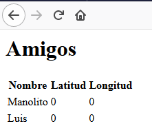

Aunque no es objetivo de la asignatura, podemos mejorar un poco su aspecto añadiendo el siguiente estilo CSS a la cabecera de `app/templates/tabla_amigos.html`:

```html
    <style>
      table {
        border-collapse: collapse;
      }
      table, th, td {
        border: 1px solid black;
        padding: 5pt;
      }
    </style>
```

y el aspecto ahora sería:

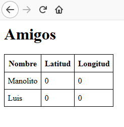

Si has llegado hasta aquí con éxito, recuerda hacer *commit* en Git del estado actual de la carpeta `amigos`.

# 4 Segunda versión de la aplicación

Hasta ahora sólo hemos presentado la tabla de amigos al usuario, pero no le damos la posibilidad de añadir/borrar/modificar la información.

Además, la estructura del código no es muy buena. Hemos definido la ruta `/amigos` y la función que debe servirla como parte de la función `create_app()` en `app/__init__.py`. Para la prueba inicial puede servir, pero a medida que añadamos rutas para manejar el resto de la funcionalidad el código de esa función sería cada vez más largo e inmanejable.

Ha llegado el momento de hacer las cosas bien.

## 4.1 Blueprints

La forma correcta de estructurar una aplicación Flask es mediante *blueprints*. Éstos se entienden como si fueran sub-aplicaciones, que aparecerán bajo diferentes rutas ante la aplicación general.

En nuestro caso, recordando que pretendíamos suministrar dos vistas, una en HTML para usar desde un navegador y otra API REST para consumir desde cualquier otro tipo de cliente, los *blueprints* nos permitirán separar esas funcionalidades en las rutas `/html` y `/api`, por ejemplo. No obstante el código forma parte de la misma aplicación, por lo que comparte el objeto `db` para acceder a la base de datos, el modelo de datos, y las funciones adicionales que queramos programar y que puedan ser útiles para ambas vistas. En esta aplicación tan sencilla no hay más funciones extra, pero una aplicación real toda la funcionalidad de negocio podría ser compartida entre ambas vistas.

Cada *blueprint* dará lugar a un subdirectorio dentro de `app` y cada uno de ellos contendrá su propio `__init__.py` y su propio `views.py`. No tienen su propio `model.py` porque el modelo de datos es común a ambas vistas.

La nueva estructura de carpetas será por tanto:

```bash
amigos/
    ├── app/
    │   ├── api/
    │   │   ├── __init__.py
    │   │   └── views.py
    │   ├── html/
    │   │   ├── __init__.py
    │   │   └── views.py
    │   ├── __init__.py
    │   ├── models.py
    │   └── templates/
    ├── config.py
    ├── instance/
    │   └── config.py
    ├── migrations/
    └── lanzar.py
```

La vista “api” no usa templates, esos sólo son necesarios para la vista “html”, por lo que decidimos no moverlos de donde estaban.

## 4.2 Blueprint html

El fichero `app/html/__init__.py` debe limitarse a declarar una variable de tipo `Blueprint`, con el nombre del blueprint en cuestión (`html`) e importar sus vistas. Para ello el código es:

```python
from flask import Blueprint

html = Blueprint('html', __name__)

from . import views
```

El fichero `app/html/views.py` contiene las funciones que generarán las vistas de cada posible URL. De momento sólo habíamos hecho la vista para la url `/amigos`, que era la que generaba la tabla de amigos. Por tanto de momento tendremos sólo lo siguiente:

```python
from flask import render_template
from . import html
from ..models import Amigo

@html.route("/amigos")
def tabla_amigos():
    """
    Obtiene la lista de amigos de la base de datos y la
    devuelve en una tabla HTML.
    """
    amigos = Amigo.query.all()
    return render_template("tabla_amigos.html",
                           amigos=amigos)
```

Observa lo siguiente:

Finalmente, es necesario cambiar la función `create_app()`, puesto que ya no se definen dentro de ella rutas ni manejadores, sino que se limitará a importar el *blueprint* `html` y montarlo en la ruta `/html`.

El nuevo contenido de `app/__init__.py` será este:

```python
from flask import Flask
from flask_sqlalchemy import SQLAlchemy
from flask_migrate import Migrate
from config import app_config

# Inicializar db, que conecta con la base de datos
db = SQLAlchemy()

def create_app(config_name):
    # La app se crea y configura como antes
    app = Flask(__name__, instance_relative_config=True)
    app.config.from_object(app_config[config_name])
    app.config.from_pyfile('config.py')
    db.init_app(app)
    migrate = Migrate(app, db)

    # Pero ahora no implementamos aquí funciones ni rutas
    # eso lo hacen los blueprints. Aquí simplemente registramos
    # esos blueprints para "montarlos" en una ruta
    from .html import html as html_blueprint
    app.register_blueprint(html_blueprint, url_prefix='/html')

    return app
```

Realiza las modificaciones que se acaban de explicar y comprueba si han funcionado correctamente. Para ello lanzas el servidor de desarrollo (`flask run`) como habíamos hecho hasta ahora, y pruebas con el navegador a conectarte a la ruta `http://<ip-de-tu-ubuntu>:5000/html/amigos` (observa cómo hay que poner `/html` para acceder a las rutas del blueprint html).

Si todo ha ido bien no olvides hacer *commit* en git de los cambios.

### 4.2.1 Añadir enlaces a nuevas acciones

Queremos que la tabla contenga dos columnas más, una con un enlace para “modificar” y otra con otro enlace para “borrar”. Si, por ejemplo, el `id` del amigo que estamos mostrando en esa fila es `id=1`, los enlaces en cuestión apuntarían a `/html/edit_amigo/1` y `/html/delete_amigo/1`, respectivamente, es decir, la tabla una vez renderizada en HTML contendría una fila que diría:

```html
        <tr>
          <td>Manolito</td>
          <td>0</td>
          <td>0</td>
          <td><a href="/html/edit_amigo/1">Modificar</a></td>
          <td><a href="/html/delete_amigo/1">Borrar</a></td>
        </tr>
```

**Ejercicio**

Modifica `app/templates/tabla_amigos.html` para que incluya dichos enlaces. Ten en cuenta que en la variable `amigo.id` tienes el id de cada amigo de la tabla.

**Ejercicio**

Añade al final de la tabla (fuera de ella) otro enlace que diga “Añadir amigo” y que apunte a la URL apropiada (consulta el apartado Vista HTML si no recuerdas el diseño de rutas y verbos).

Comprueba tras los ejercicios anteriores que conectando a `/html/amigos` la tabla aparece ya con los enlaces apropiados. Si pinchas cualquiera de ellos obviamente no funcionarán, ya que las URLs a que apuntan no están aún implementadas en Flask. No obstante haz *commit* de este estado.

### 4.2.2 Implementando acción “borrar”

Edita `app/html/views.py` para añadir una función que se ocupe de la ruta `/delete_amigo/<id>`. Observa que como parte de la ruta va el ID del amigo a eliminar. Flask tiene soporte para extraer ese id de la ruta y pasarlo como parámetro a la función, simplificando la implementación que queda tan simple como buscar en la base de datos ese amigo (devolver 404 si no existe) y borrarlo. Seguidamente queremos devolver la misma vista de la tabla de amigos, por lo que podemos hacer una redirección a la URL adecuada.

```python
from flask import render_template, redirect, url_for
from .. import db
# Resto igual
# ...

@html.route("/delete_amigo/<int:id>")
def delete_amigo(id):
    """
    Borra un amigo de la base de datos
    """
    # El método get_or_404 proporcionado por SQLAlchemy
    # se ocupa de generar un error 404 si el id no está en
    # la base de datos
    amigo = Amigo.query.get_or_404(id)
    # Una vez obtenido, lo borramos
    db.session.delete(amigo)
    db.session.commit()

    # Y redireccionamos a la vista /amigos
    return redirect(url_for('html.tabla_amigos'))
```

Observa cómo finaliza la función. El método `redirect()` de Flask envía un código 302 al cliente con la URL que le pases como parámetro. El navegador, al recibir el 302 hará otro GET a la URL indicada y así cargará otra página. Pero observa que hemos evitado pasarle una URL concreta (como sería `/html/amigos`), sino que hemos optado por usar la función `url_for()` a la que se le pasa el nombre de una función dentro de un módulo (en este caso módulo `html`, función `tabla_amigos`) para que sea Flask quien averigue qué ruta corresponde a esa función. Esto es más flexible pues nos permite cambiar el punto de montaje del Blueprint, o el nombre de la ruta dentro del mismo, sin romper nada.

Ejecuta esta versión. Abre el navegador y activa las herramientas para desarrolladores y la pestaña del tráfico de red. Accede a la url del servicio para ver la tabla de amigos y pulsa en el enlace para borrar uno. Comprueba que aparece de nuevo la tabla, pero ya sin ese amigo.

Observa las peticiones HTTP que ha hecho el navegador. ¿Puedes ver la redirección (código 302)?

### 4.2.3 Implementando las acciones de editar/añadir amigo

Necesitamos un nuevo *template*, que será el formulario HTML con los datos del amigo en cuestión (o en blanco si es un amigo nuevo). No es objetivo de la asignatura explicar cómo se escribe un formulario HTML. Simplemente comentar que en este caso, el formulario tendrá tres campos visibles para el usuario: nombre, latitud y longitud del amigo, y uno invisible, el `id` del amigo. El `id` es necesario para que cuando el servidor reciba los datos sepa qué amigo debe modificar en la base de datos, pero no debe ser visible al usuario porque éste no puede cambiar el id de un elemento de la base de datos.

Habría muchas más cosas que explicar sobre formularios, tales como la inclusión de comprobaciones en el lado cliente (por ejemplo, limitar el número de caracteres de un campo, forzar a que el usuario deba poner algo en los campos obligatorios, protegerse de ataques CSRF, etc. Flask proporciona el paquete `flask-wtf` para simplificar la creación de formularios seguros, pero no la usaremos aquí).

Escribe lo siguiente en `app/templates/edit_amigo.html`:

```html
<html>
  <head>
    <meta charset="utf-8">
    <title>Amigo - Modificar datos</title>
  </head>
  <body>
  <h1>Amigo - Modificar datos</h1>
  <form action="/html/save_amigo" method="POST">
    <input type="hidden" name="id" value="{{amigo.id}}"/>
    <label for="name">Nombre</label>
    <input type="text" name="name" value="{{amigo.name}}"></br>
    <label for="longi">Logitud</label>
    <input type="text" name="longi" value="{{amigo.longi}}"></br>
    <label for="lati">Latitud</label>
    <input type="text" name="lati" value="{{amigo.lati}}"></br>
    <input type="submit" value="Enviar"></form>
  </body>
</html>
```

Lo más importante del código anterior es la línea `<form action=...>`, pues es la que especifica qué ocurrirá cuando el usuario pulse el botón “Enviar”, una vez haya modificado a su antojo los campos del formulario. Y en esa línea estamos diciendo que haga una petición `POST` (sólo se permite POST o GET), a la url `/html/save_amigo`, donde habrá otra función python (aún por escribir) que guarde los cambios en la base de datos.

Este *template* que acabamos de escribir nos sirve tanto para el caso en que estemos editando los datos de un amigo concreto, como para el caso en que estemos creando datos para un amigo nuevo. El formulario es el mismo, sólo que la variable `amigo` no tendría ningún valor en el segundo caso (valdrá `None`).

Ese template nos sirve para responder tanto a la petición `GET /html/edit_amigo/<id>` como a `GET /html/new_amigo`. Edita `app/html/views.py` y añade las funciones siguientes:

```python
@html.route("/edit_amigo/<int:id>")
def edit_amigo(id):
    """
    Presenta un formulario para obtener datos a modificar de un amigo
    """
    amigo = Amigo.query.get_or_404(id)
    # Rellenar el template con los datos de este amigo y presentar
    # el formulario al usuario
    return render_template("edit_amigo.html", amigo=amigo)

@html.route("/new_amigo/")
def new_amigo():
    """
    Presenta un formulario para obtener datos para crear nuevo amigo
    """
    # No tenemos datos de ningún amigo previo
    # Pero podemos usar el mismo template
    return render_template("edit_amigo.html", amigo=None)
```

Fíjate que la función `new_amigo()` hace uso del mismo *template* que la función `edit_amigo()`, pero haciendo `amigo=None`.

Quizás podrías pensar que eso causará errores al renderizar el *template*, puesto que si `amigo` es `None` ¿qué pasará al intentar acceder a `amigo.id` o `amigo.name`? El temor es razonable, pero `jinja2` es lo bastante listo como para dejar en blanco esos valores en caso de que su evaluación produzca excepciones como es el caso. Por tanto el usuario verá un formulario completamente vacío donde poder introducir información sobre el nuevo amigo.

Y lo que es mejor, el campo oculto `id` también tiene como valor la cadena vacía. Esto permite usar la misma URL en el POST, tanto para modificar un amigo, como para crear uno nuevo. La función que reciba los datos del formulario sabrá si se trata de un nuevo amigo o de uno existente gracias al campo oculto `id` del formulario.

Para completar esta funcionalidad sólo queda escribir la función que responda al `POST /html/save_amigo`. Esta función deberá extraer los datos del formulario (que recibirá en el cuerpo de la petición) y decida en base a ellos si actualizar un amigo de la base de datos o crear uno nuevo.

Para acceder a los datos del formulario debemos importar de `flask` la variable `request`, que es una especie de variable global (pero única para cada petición recibida) que nos dará acceso a los datos del FORM. Debemos validar esos datos (por ejemplo, si el usuario no ha introducido nombre, o si el nombre ya existía, rechazaremos la creación del nuevo amigo). Una forma sencilla de generar errores es usar la función `abort` de `flask`, que importaremos también.

Edita `app/html/views.py` y añade la siguiente función:

```python
# Añadir nuevos imports en la primera línea
from flask import render_template, redirect, url_for, request, abort

# ...
@html.route("/save_amigo", methods=["POST"])
def save_amigo():
    id = request.form.get("id")
    if id is None or id == "":
        # En este caso se trata de un amigo nuevo, lo creamos
        name = request.form.get("name")
        if not name:
            # Si falta el nombre, devolvemos un error HTTP 422
            abort(422)
        # Para lati y longi permitimos que estén ausentes, y en ese caso
        # les damos un valor por defecto de "0"
        lati = request.form.get("lati", "0")
        longi = request.form.get("longi", "0")

        # Creamos el amigo y lo añadimos a la base de datos
        amigo = Amigo(name=name, lati=lati, longi=longi)
        db.session.add(amigo)
        db.session.commit()
    else:
        # En este caso se trata de un amigo de la base de datos
        amigo = Amigo.query.get_or_404(int(id))
        # Modificamos los campos que vengan en el formulario
        name = request.form.get("name")
        if name:
            amigo.name = name
        lati = request.form.get("lati")
        if lati:
            amigo.lati = lati
        longi = request.form.get("longi", "0")
        if longi:
            amigo.longi = longi
        # Una vez modificado, lo guardamos a la base de datos
        db.session.commit()
    # Redireccionamos hacia la tabla-lista de amigos
    return redirect(url_for("html.tabla_amigos"))
```

Observa los siguientes aspectos de este código:

- Para leer los datos que llegan del formulario, usamos la variable global `request`, que es la petición enviada por el navegador, y dentro de ella su campo `form` que es un diccionario python cuyas claves son las que hayamos puesto en el formulario y los valores los introducidos por el usuario.
- Podríamos acceder por ejemplo al nombre del amigo con `request.form["name"]`, pero esto podría fallar si el cliente no ha enviado ese campo (aunque tal cosa no puede pasar si el cliente es el navegador web usando nuestra propia página, pero podría ocurrir desde un cliente mal programado o malintencionado). Para evitar posibles problemas usamos `request.form.get("name")`, que no rompe si `"name"` no está en el formulario, sino que devuelve `None`.
- Observa cómo comprobamos que `"id"` esté en el formulario y si no está o es vacío, creamos un nuevo amigo.
- El campo `"name"` lo hacemos obligatorio. Si no viene, generamos un error 422 (HTTP Unprocessable Entity). Los campos `"longi"` y `"lati"` los hacemos opcionales y si no vienen les damos el valor por defecto `"0"`. Usando `.get()` es tan sencillo como pasar un segundo parámetro que sería el valor por defecto.
- Los comandos para crear el amigo y añadirlo a la base de datos son iguales a los que hicimos cuando creamos “a mano” los dos primeros amigos de ejemplo, desde un intérprete python.
- En caso de que venga un `"id"`, lo usamos para sacar de la base de datos a ese amigo (o generamos un error 404 si no existe), y modificamos en él los campos que nos lleguen del formulario.

Implementa los cambios anteriores y lanza de nuevo el servidor.

Accede desde el navegador a `http://<ip-de-tu-ubuntu>:5000/html/amigos` y prueba que los enlaces de modificar y añadir funcionan correctamente.

Si todo va bien, recuerda hacer *commit* de los cambios realizados.

# 5 Tercera versión de la aplicación

De la sección anterior tenemos listo un servidor que es apropiado para interactuar con un usuario humano, a través de un navegador Web, pero no es apropiado para interactuar con un cliente que sea otra aplicación (por ejemplo, si queremos ver o modificar la lista de amigos desde línea de comandos, a través de un *script* en python, o desde una aplicación móvil desarrollada en Java o Kotlin).

Para lo segundo, tenemos que programar una versión del servidor que en lugar de responder con HTML, responda JSON, que es más fácil de *parsear*, y que en lugar de recibir los datos en un `form` (formulario HTML), los reciba también en JSON. Y preferiblemente, para acercarnos más a la filosofía REST, que use correctamente los verbos HTTP, es decir, que use `DELETE` en lugar de `GET` cuando quiera eliminar un amigo de la base de datos, o `PUT` en lugar de `POST` cuando quiera modificar uno. También debe usar nombres de recursos que no incluyan el verbo. Por ejemplo, borrar un amigo cuyo id es 1 debería hacerse con la petición HTTP `DELETE /amigo/1`, en lugar de usar `GET /delete_amigo/1` como hacíamos en la versión HTML (donde no quedaba otro remedio que hacerlo así porque el navegador Web no puede emitir peticiones `DELETE`).

También nos será útil (por razones relacionadas con otra práctica futura), tener una forma de encontrar a un amigo en la base de datos por su nombre, en lugar de por su id. Por ejemplo, poder hacer un `GET /amigo/byName/Manolo`.

Detallaremos por tanto a continuación qué URLs compondrán la API y qué verbos HTTP se pueden usar en cada una de ellas.

## 5.1 Diseño de la API

En nuestro caso habrá dos rutas importantes:

- `/amigos` a la que se puede hacer `GET` para obtener la lista JSON de amigos, o `POST` para añadir un amigo nuevo (cuyos datos irán en el cuerpo del POST y en JSON).
- `/amigo` que se completa con el `id` del amigo (por ejemplo `/amigo/1`) y a la que se puede hacer `GET` para obtener los datos del amigo, `PUT` para actualizar esos datos o `DELETE` para borrar el amigo. También permitiremos `/amigo/byName/<nombre>` para buscar un amigo por su nombre.

La lista exhaustiva de todas las combinaciones de verbos HTTP permitidos y las URLs de cada uno, así como la estructura del JSON que retorna cada caso, o el JSON que hay que enviarle conformarían la *documentación de la API*.

Escribir esa documentación a mano es perfectamente posible, pero están ganando mucha popularidad herramientas para automatizar la creación de este tipo de documentaciones, siendo la más importante de ellas [swagger](https://swagger.io/tools/swagger-editor/), que utiliza YAML o JSON como lenguaje para describir la API (siguiendo el estándar [OpenAPI](https://github.com/OAI/OpenAPI-Specification), y es capaz de crear documentación HTML y hasta código de ejemplo a partir de esa descripción.

Se sale de los objetivos de la asignatura la descripción de esta especificación, pero en el Anexo tienes cómo sería el fichero YAML completo que describe la API que vamos a implementar. Lo más útil del anexo es que puedes copiar y pegar esa descripción YAML en el [Editor online de Swagger](https://editor.swagger.io/) para generar automáticamente la documentación. La documentación generada es interactiva (puedes colapsar o expandir los detalles), y puede serte útil tenerla como referencia mientras vamos implementando la API. Con todo colapsado tiene este aspecto:

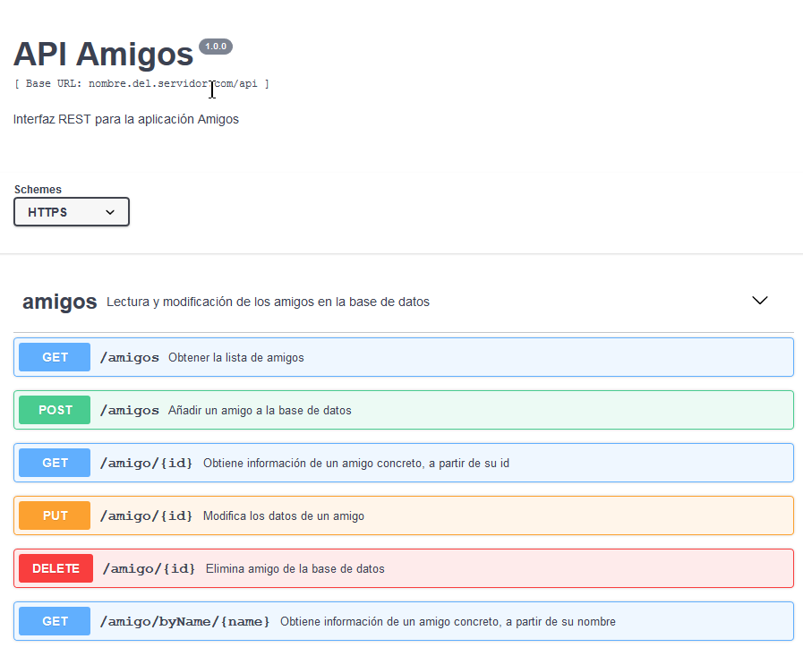

## 5.2 Implementación de la API REST

Flask es perfecto para implementar este tipo de APIs. Ya lo hemos usado antes para la interfaz html, y entonces hicimos uso de *templates* y de jinja2 para retornar HTML. Ahora que tenemos que retornar JSON la cosa es más sencilla aún, pues no necesitamos *template* alguno. Además ahora recibiremos los datos (en las peticiones `POST` o `PUT`) también en JSON, en lugar de un formulario HTML.

Para retornar JSON, Flask contiene la función `jsonify()` que convierte a JSON cualquier variable Python que sea una lista o un diccionario y cuyos elementos sean a su vez listas o diccionarios. Para recibir JSON, Flask ya incorpora en la variable `request` el campo `request.json`, que es el resultado de haber convertido el JSON recibido en una estructura de datos Python (un diccionario o lista), directamente usable por nuestro programa.

Podemos además reusar todo el código que ya teníamos que creaba la aplicación, la configuraba y la conectaba con la base de datos, simplemente haciendo que la parte de la API REST sea otro *blueprint* que podemos montar en la ruta `/api`.

### 5.2.1 Registro del Blueprint

Es muy similar a lo que ya hicimos para el blueprint html. Edita el fichero `app/api/__init__.py` y escribe lo siguiente:

```python
from flask import Blueprint

api = Blueprint('api', __name__)

from . import views
```

Edita `app/__init__.py` y añade las dos líneas que registran este blueprint bajo la ruta `/api`:

```python
# Todo igual que antes...

def create_app(config_name):
    # Todo igual que antes...

    from .api import api as api_blueprint
    app.register_blueprint(api_blueprint, url_prefix='/api')

    return app
```

### 5.2.2 Implementación de GET /amigo/*id*

Edita el fichero `app/api/views.py`. Vamos a crear una primera ruta para retornar un amigo concreto, dado su `id`.

```python
from flask import request, abort, jsonify
from .. import db
from . import api
from ..models import Amigo

@api.route("/amigo/<int:id>")
def get_amigo(id):
    """
    Retorna JSON con información sobre el amigo cuyo id recibe como parámetro
    o un error 404 si no lo encuentra.
    """
    amigo = Amigo.query.get_or_404(id)
    amigodict = {'id': amigo.id, 'name': amigo.name,
                 'lati': amigo.lati, 'longi': amigo.longi}
    return jsonify(amigodict)
```

Comentarios:

- El primer `import` nos proporciona la función `jsonify()`, clave para retornar la respuesta en JSON en vez de HTML.
- El resto de `import` son necesarios para obtener la variable que representa a la base de datos, `db`, la que representa al blueprint, `api` (que usaremos para decoradores como `@api.route()`) y para el modelo de `Amigo` que usaremos para *queries* a la base de datos (y para instanciar amigos nuevos más adelante).
- La función `get_amigo()` que estamos implementando aquí recibe como parámetro un `id` que el cliente especificó como parte de la ruta al recurso. Lo usamos para buscar ese amigo en la base de datos.
- Una vez obtenido el objeto `amigo`, lo usamos para rellenar los campos del diccionario python `amigodict`.
- `jsonify()` se ocupa de convertir a JSON el diccionario en cuestión, y además de poner la cabecera HTTP que indica el `Content-type` apropiado para que el cliente sepa que la respuesta viene en JSON.

### 5.2.3 Probando si funciona

Una forma es abrir el navegador web y visitar la URL `http://<ip-de-tu-ubuntu>:5000/api/amigo/1`, por ejemplo, y ver si recibimos el JSON con la información de ese amigo (asegúrate de que exista, quizás lo has borrado antes mientras jugabas con la interfaz html. Si no existe crea otro con la interfaz html y averigua su id, por ejemplo editando sus datos desde la interfaz html).

Usar el navegador para probar una API REST no es conveniente. Si el método es `GET`, como en el caso anterior, funcionará, pero si queremos probar `PUT` o `DELETE` o incluso un `POST` pero enviando JSON en vez de un form, ya no podremos usar el navegador para estas pruebas.

Lo habitual es hacer las pruebas desde línea de comandos. `curl` suele ser la herramienta habitual para ello, pero su sintaxis no es muy cómoda. Python tiene una herramienta más amigable, llamada `http`, que es la que usaremos.

Instala `http` con el siguiente comando (asegúrate de hacerlo mientras estás dentro del entorno virtual)

```bash
 (flaskenv) $ pip install httpie
```

Lanza el servidor de desarrollo con:

```bash
 (flaskenv)$ FLASK_APP=lanzar.py flask run -h 0.0.0.0
```

Eso le dejará escuchando en el puerto 5000. En otra terminal, activa el entorno virtual (para tener acceso a la herramienta `http` que acabamos de instalar) y prueba a hacer una petición `GET` como la siguiente:

```bash
(flaskenv) $ http GET localhost:5000/api/amigo/1
```

La respuesta del servidor será visible en la terminal, coloreada sintácticamente para que sea más fácil de leer, e incluyendo las cabeceras HTTP de la respuesta. Observa cómo el `Content-Type` es `application/json`. Si recibes un error 404 es que no existe amigo con ese id (quizás lo borraste de la base de datos). Prueba con otros.

Observa que, ya que hemos montado el nuevo *blueprint* en la ruta `/api`, es necesario añadir ese prefijo a `/amigo/<id>`.

### 5.2.4 Implementación de GET /amigo/byName/*name*

De forma análoga podemos escribir un método que busque un amigo por su nombre. Añade a `app/api/views.py` la siguiente función:

```python
@api.route("/amigo/byName/<name>")
def get_amigo_by_name(name):
    """
    Busca el amigo por su nombre en la base de datos. Si no lo encuentra
    retorna un error 404. Si lo encuentra retorna el JSON con sus datos
    """
    amigo = Amigo.query.filter_by(name = name).first()
    if not amigo:
        abort(404, "No se encuentra ningún amigo con ese nombre")
    amigodict = {'id': amigo.id, 'name': amigo.name,
                 'lati': amigo.lati, 'longi': amigo.longi}
    return jsonify(amigodict)
```

Fíjate que es casi idéntica a la que hicimos antes para el `id`, salvo por la forma en que buscamos al amigo en la base de datos. En este caso usamos un `Amigo.query.filter_by()`. El resultado es una lista especial (implementada en SQLAlchemy) de la que tomamos el primer elemento mediante el método `.first()`. Si el nombre no aparece en la base de datos obtendremos `None`, cosa que verificamos seguidamente para generar un error 404 en ese caso. Una vez encontrado el amigo, la conversión a JSON es como antes.

Utiliza el comando `http` para acceder a la URL que acabamos de programar. Comprueba que recupera correctamente amigos de la base de datos, o que genera un 404 para nombres no existentes.

Haz *commit* de los cambios.

**Nota**. La base de datos usa por defecto una codificación que la hace insensible a mayúsculas, minúsculas e incluso acentos. Esto significa que puedes buscar por el nombre `andres` y te retornaría correctamente un amigo cuyo nombre en la base de datos es `Andrés`. Esto en principio es conveniente, pero ya que hemos puesto el requisito de que el nombre sea único, eso también implica que no podemos meter nombres que se diferencien sólo en si llevan o no tilde como “José” y “Jose”. Corregir este aspecto se sale de los objetivos de la práctica.

### 5.2.5 Implementación de GET /amigos

No daremos código para este caso. Debes implementarlo por tí mismo/a.

**Ejercicio**

Completa la función siguiente, que debes añadir a `app/api/views.py`

```python
@api.route("/amigos")
def list_amigos():
     """
     Retorna un JSON con la lista de amigos. Cada amigo es un diccionario
     con los campos 'id', 'name', 'lati' y 'longi'
     """
     # A completar
```

### 5.2.6 Implementación de PUT /amigo/*id*

Cuando se recibe el verbo `PUT` sobre la ruta que identifica a un amigo concreto (por su id), hay que actualizar los datos de ese amigo, que son recibidos a través de `request.json`. El siguiente código te muestra cómo:

Edita `app/api/views.py` y añade esta función:

```python
@api.route("/amigo/<int:id>", methods=["PUT"])
def edit_amigo(id):
    """
    Modifica en la base de datos el amigo cuyo id recibe como parámetro.

    Retorna el JSON con el amigo tras la modificación
    """
    # Obtenemos el amigo a partir de su ID
    amigo = Amigo.query.get_or_404(id)

    # Comprobamos que hemos recibido JSON como parte del PUT
    if not request.json:
        abort(422, "No se ha enviado JSON")

    # Intentamos extraer campos del JSON (si no están presentes)
    # la extracción retornará None
    name = request.json.get("name")
    lati = request.json.get("lati")
    longi = request.json.get("longi")
    # Usamos los campos que estén presentes para actualizar el objeto amigo
    if name:
        amigo.name = name
    if lati:
        amigo.lati = lati
    if longi:
        amigo.longi = longi

    # Finalmente, si hemos cambiado algo en el objeto amigo, hacemos
    # el commit a la base de datos para que se guarden las modificaciones
    if name or lati or longi:
        db.session.commit()

    # Y retornamos el JSON con los nuevos datos
    amigodict = {"id": amigo.id, "name": amigo.name,
                 "longi": amigo.longi, "lati": amigo.lati }
    return jsonify(amigodict)
```

Podemos probar si funciona correctamente desde línea de comandos:

```bash
(flaskenv) $ http --json PUT localhost:5000/api/amigo/1 lati=12
```

En este ejemplo estamos cambiando el campo `lati` del amigo cuyo `id` es 1. El comando `http` permite que especifiquemos nombres de campos y valores en la línea de comandos mediante `campo=valor`, y con la opción `--json` se ocupa de generar un JSON con esa información que es enviada al servidor en el cuerpo del `PUT`.

### 5.2.7 Implementación de DELETE /amigo/*id*

Este es un ejercicio que debes implementar por ti mismo/a. Toma como inspiración el código de la función anterior, para ver cómo se especifica qué verbo HTTP aceptas (en este caso debes poner `DELETE` en vez de `PUT`), y el código que usaste en el *blueprint* html para el borrado de un amigo.

**Ejercicio** Edita `app/api/views.py` y añade la función siguiente que debes completar.

```python
@api.route(# ... a completar ... )
def delete_amigo(id):
     """
     Elimina un amigo cuyo id recibe como parámetro de la base de datos.
     """
     # A completar
     # En este caso no hay nada que retornar, pero es habitual hacer que
     # el código de estado HTTP sea 204 "No content" en lugar de 200 "OK"
     return ('', 204)
```

Lanza el servidor `flask run` y desde otra terminal (pero desde con el entorno virtual activado) ejecuta el siguiente comando para probar a borrar un amigo (el siguiente ejemplo se usa como `id` el valor 5, asegúrate de usar uno que figure en tu base de datos):

```bash
(flaskenv) $ http DELETE localhost:5000/api/amigo/5
```

### 5.2.8 Implementación de POST /amigos

Siguiendo la filosofía típica de diseño de una API REST, para crear recursos se ha de usar el verbo POST y la URL ha de ser la misma de la que luego se obtiene la lista de recursos creados. Ya que los amigos los obtenemos con un `GET /amigos`, la forma de crear uno nuevo será con `POST /amigos`.

Los datos del amigo a crear se reciben en el cuerpo del POST, pero en esta ocasión no será en un formulario, como en la vista html, sino en json.

Edita el fichero `app/api/views.py` para añadir la siguiente función que implementaría esta última ruta. Fíjate que la forma de acceder a los parámetros es la misma que la que ya usamos para el `PUT`, pero en esta ocasión debemos asegurarnos de que se proporciona un nombre y de que éste no existe ya en la base de datos. Fíjate cómo lo hacemos:

```python
@api.route("/amigos", methods=["POST"])
def new_amigo():
    """
    Modifica en la base de datos añadiendo un amigo cuyos datos
    recibe en JSON.

    Retorna el JSON con el amigo tras la creación, para que el cliente
    pueda conocer el id del amigo recién creado.
    """

    # Comprobamos que hemos recibido JSON como parte del PUT
    if not request.json:
        abort(422, "No se ha enviado JSON")

    # Intentamos extraer campos del JSON (si no están presentes)
    # la extracción retornará None
    name = request.json.get("name")
    # Si no hay nombre, rechazamos la petición
    if not name:
        abort(422, "El JSON no incluye el campo 'name'")

    # Si el nombre ya existe en la base de datos, también lo rechazamos
    amigo = Amigo.query.filter_by(name = name).first()
    if amigo:
        abort(422, "Ya existe un amigo con ese nombre")

    # En caso contrario, tomamos latitud y longitud. Si no vienen les
    # damos un valor de 0
    lati = request.json.get("lati", "0")
    longi = request.json.get("longi", "0")

    # Creamos un nuevo amigo con esos datos
    amigo = Amigo(name=name, lati=lati, longi=longi)
    db.session.add(amigo)
    db.session.commit()

    # Y retornamos el JSON con los datos del nuevo amigo
    amigodict = {"id": amigo.id, "name": amigo.name,
                 "longi": amigo.longi, "lati": amigo.lati }
    return jsonify(amigodict)
```

Una vez implementada la función anterior, relanza el servidor y comprueba que puedes crear nuevos amigos usando el comando `http` del siguiente modo:

```bash
(flaskenv) $ http --json POST localhost:5000/api/amigos name=Javier
```

Comprueba que Javier ha sido añadido a la lista de amigos, con coordenadas 0, 0 por defecto. Crea otros amigos con otras coordenadas. Prueba a meter un amigo que ya estuviera en la base de datos, o a no especificar el nombre y verifica que el servidor retorna los errores apropiados.

# 6 Despliegue en contenedores

Una vez tenemos la aplicación completa, debemos abandonar el servidor de desarrollo de Flask y cambiarlo por uno de producción (gunicorn), lanzando nuestra aplicación en un contenedor, y poniéndolo “detrás” de otro contenedor que ejecute nginx haciendo de proxy, como ya hicimos en la sesión anterior con el ejemplo “hola-flask”.

La arquitectura del despliegue será la siguiente:

[figure not shown]

## 6.1 Creación del contenedor para la aplicación Flask

Basándonos en el `Dockerfile` de la sesión anterior, basta cambiarlo ligeramente para añadirle las bibliotecas python que usamos ahora y el nombre del *script* que contiene la variable `app`, que es ahora `lanzar.py`

La carpeta donde estará la aplicación flask dentro del contenedor será `/amigos`, y será una copia de nuestra carpeta `amigos` actual en la que hemos estado haciendo el desarrollo, con todo lo que ésta contiene (subdirectorios y scripts de configuración incluidos).

Ya que la carpeta `amigos` contiene secretos (la url a la base de datos tiene la contraseña de la misma) debemos eliminar esa información antes de copiarla a la imagen Docker. Pero entonces ¿cómo sabrá la aplicación la URL de la base de datos a la que debe conectar?

La solución es utilizar variables de entorno en la forma siguiente:

Edita el fichero `instance/config.py` y cámbialo a lo siguiente

```python
# Definición de secretos a usar por la app
import os

SQLALCHEMY_DATABASE_URI = os.getenv("DATABASE_URI", "sqlite://")
```

Lo que hacemos ahora es utilizar el módulo estándar python `os` que permite acceder a las variables de entorno. Si la variable de entorno llamada `DATABASE_URI` existe, usamos su valor y lo copiamos a la variable python adecuada. Si no existe, le damos el valor por defecto `sqlite://` que es una base de datos minimalista que se almacena en RAM y que obviamente estará vacía, y por tanto no funcionará.

Ya que acabamos de ver cómo obtener desde python variables de entorno, podemos usar el mismo truco como parte del script `lanzar.py` para tomar de una variable de entorno el “modo” de lanzamiento, ya sea `"production"` o `"development"`.

Edita el fichero `lanzar.py` y cámbialo a lo siguiente:

```python
# Importar la función create_app desde la carpeta app
from app import create_app
import os

# Usarlo para instanciar la aplicacion
modo = os.getenv("DEPLOYMENT_MODE", "production")
app = create_app(modo)
```

Aquí esperamos una variable de entorno llamada `DEPLOYMENT_MODE` y si no existe le damos el valor por defecto `"production"`.

Para lanzar ahora la aplicación desde el entorno virtual será necesario definir estas variables de entorno, es decir, haríamos:

```bash
(flaskenv) $ export DEPLOYMENT_MODE=development
(flaskenv) $ export DATABASE_URI=mysql+pymysql://amigosuser:amigospass@172.18.0.2/amigosdb
(flaskenv) $ FLASK_APP=lanzar.py flask run -h 0.0.0.0
```

Para lanzarla desde un contenedor, tendremos que pasar esas variables de entorno al contenedor, como veremos luego.

Ya está todo listo para *contenedorizar* la aplicación. Escribe lo siguiente en un fichero llamado `Dockerfile` dentro de la carpeta `amigos`:

```
FROM python:3.7
RUN pip install flask && pip install gunicorn
RUN pip install flask-sqlalchemy pymysql flask-migrate

RUN mkdir /amigos
COPY . /amigos
WORKDIR /amigos

EXPOSE 5000
CMD ["/usr/local/bin/gunicorn", "-b",  "0.0.0.0:5000", "-w", "4", "lanzar:app"]
```

Una vez copiado lo anterior al `Dockerfile` ejecuta en la carpeta `amigos` el siguiente comando:

```bash
$ docker build -t amigos:1.0 .
```

Comprueba con `docker images` que la imagen `amigos 1.0` ha sido creada.

## 6.2 Configuración de nginx

Sitúate en la carpeta padre de `amigos` y crea otra llamada `sitios_nginx`.

Escribe dentro de esa carpeta un fichero `default.conf` que contenga lo siguiente:

```python
server {
    listen       80;
    server_name  localhost;

    location / {
        resolver 127.0.0.11;
        proxy_pass http://amigos:5000;
    }
}
```

Como ves en este caso hemos simplificado mucho la configuración. Nginx no va a servir archivos estáticos en esta ocasión, sino redirigir todo hacia la aplicación flask, que está en el nodo llamado `amigos`, puerto 5000. No es necesario en esta ocasión usar expresiones regulares para capturar la ruta, ya que por defecto nginx al actuar como proxy la pasará a flask la misma ruta que haya recibido del cliente.

## 6.3 Despliegue

Para que todo funcione, hay que desplegar tres contenedores como hemos visto en la figura. Debes estar situado en la carpeta raiz de la sesión de hoy, es decir, la carpeta que tiene como subcarpetas `amigos`, `basedatos` y `sitios_nginx`.

Las siguientes secciones detallan cómo. Ya que los comandos docker a ejecutar son largos y farragosos puede ser interesante guardarlos en tres scripts llamados por ejemplo `lanza-basedatos.sh`, `lanza-flask.sh` y `lanza-nginx.sh`.

### 6.3.1 Contenedor con la base de datos

Ese ya lo tenemos funcionando, pero recordamos aquí el comando necesario para arrancarlo por si lo hubieras parado:

```bash
$ docker run --name basedatos \
  -e MYSQL_ROOT_PASSWORD=claveroot \
  -e MYSQL_USER=amigosuser \
  -e MYSQL_DATABASE=amigosdb \
  -e MYSQL_PASSWORD=amigospass \
  -v $(pwd)/basedatos:/var/lib/mysql \
  --rm --network pruebas -d mariadb
```

### 6.3.2 Contenedor con la aplicación Flask

Este consiste en activar la imagen que hemos creado en el apartado anterior, pero pasándole como variables de entorno las que necesita para conocer el modo de despliegue (usaremos “production” ahora) y la URL a la base de datos (usaremos ahora el nombre del nodo “basedatos” en lugar de su IP, gracias al servidor DNS incluido en docker).

El comando es por tanto:

```bash
$ docker run --name amigos \
   -e DEPLOYMENT_MODE=production \
   -e DATABASE_URI=mysql+pymysql://amigosuser:amigospass@basedatos/amigosdb \
   --rm -d --network pruebas amigos:1.0
```

> Comprueba con `docker ps` que está en ejecución. No podemos conectar a él porque el puerto 5000 en que escucha es interno al contenedor. Hasta que no despleguemos nginx que actuará de proxy, será inaccesible.

### 6.3.3 Contenedor con nginx

El despliegue de nginx es más simple que el usado en la sesión anterior porque en esta ocasión no tiene que acceder a carpetas `html` con contenidos estáticos, y por tanto no necesitamos montar esos volúmenes, sino tan sólo el que contiene `default.conf`. Importante la redirección del puerto 80 para que sea accesible desde el exterior.

```bash
$ docker run --rm -d --network pruebas --name nginx \
       -v $(pwd)/sitios_nginx:/etc/nginx/conf.d \
       -p 80:80 nginx
```

## 6.4 Comprobación final

Conecta el navegador a la IP de tu máquina ubuntu (no necesitas especificar puerto, irá por defecto al 80) y ve a la ruta `/html/amigos`. Si todo ha ido bien, verás la tabla de amigos. Desde aquí puedes añadir, borrar o modificar amigos.

Usando el mismo navegador ve a `/api/amigos` y verás ahora la lista en JSON. Desde aquí no puedes añadir, borrar o modificar los datos, puesto que el navegador no puede hacer peticiones PUT ni DELETE, y los POST los envía sólo ante la acción *submit* de un formulario. Esta api será usada más adelante en una práctica en la que el cliente será una aplicación Android.

# 7 Ejercicios adicionales

## 7.1 Dispositivos de los amigos

Como parte de la futura práctica Android, cada “amigo” de la base de datos necesita tener un campo nuevo, llamado `device`, que será una cadena de 4096 caracteres. Estas cadenas tan largas se almacenan en un campo de tipo TEXT (dentro de SQLAlchemy sería `db.Text()`). Por defecto estas cadenas estarán vacías (es decir, contienen NULL en la base de datos, `None` al leerlas en python), pero la API REST debe permitir cambiarlas (mediante un `PUT` al correspondiente amigo).

**Ejercicio**

Usando el servidor de desarrollo `flask` para probar las modificaciones que vayas haciendo:

1. Realiza las modificaciones apropiadas en el modelo para incorporar el nuevo campo `device`.
2. Realiza la migración y el *upgrade* de la base de datos.
3. Modifica las vistas, tanto `html` como `api` para que muestren el campo `device` de cada amigo en las operaciones `GET`.
4. Modifica las vistas adecuadas para que se pueda modificar el valor del dispositivo, tanto a través del formulario HTML (ten en cuenta la observación anterior sobre el valor `"None"`) como a través de un `PUT` al amigo correspondiente. La aplicación debe aceptar que venga una cadena vacía en el campo `device`, y la guardará en la base de datos. Para las vistas jinja del formulario, si te limitas a usar el valor de `{{amigo.device}}`, saldrá la cadena `"None"` en el navegador, y si el usuario no la cambia mandará de vuelta esa cadena al servidor, que guardaría entonces la cadena `"None"` en la base de datos, en lugar de una cadena vacía. Queremos por tanto que si en la base de datos el `device` era nulo, en el formulario salga la cadena vacía, por lo que deberás poner `{{amigo.device or ''}}` para lograrlo.
5. Añade a la API una funcion que responda ante un `GET /api/devices` suministrando la lista de todos los `device` no nulos (ni cadenas vacías) en la base de datos.

Una vez has probado con el servidor de desarrollo que todo funciona correctamente:

- Finalmente rehaz (`docker build`) la imagen `amigos` con el tag `amigos:2.0` y prueba a lanzar todo en contenedores.
- Asegúrate de guardar en git no sólo los cambios que hayas hecho al código, sino también las migraciones creadas por flask-migrate, el `Dockerfile` (si has tenido que cambiarlo, en principio no hace falta) y los scripts que hayas modificado para lanzar la nueva versión.

Tras haber hecho tus experimentos, es posible que hayas dejado “basura” en los campos `device` de los amigos de la base de datos. Edítalos para que todos ellos sean la cadena vacía, pues de lo contrario habrá problemas en la práctica de Android.

# 8 Anexo

Código YAML que describe la API Amigos. Puedes copiar y pegar este código en el [Editor Online de Swagger](https://editor.swagger.io/) para navegar de forma interactiva por la documentación generada.

```yaml
swagger: "2.0"
info:
  description: "Interfaz REST para la aplicación Amigos"
  version: "1.0.0"
  title: "API Amigos"
host: "nombre.del.servidor.com"
basePath: "/api"
tags:
- name: "amigos"
  description: "Lectura y modificación de los amigos en la base de datos"
schemes:
- "https"
- "http"
paths:
  /amigos:
    get:
      tags:
      - "amigos"
      summary: "Obtener la lista de amigos"
      produces:
      - "application/json"
      responses:
        200:
          description: "OK"
          schema:
            type: array
            items:
              $ref: "#/definitions/Amigo"
    post:
      tags:
      - "amigos"
      summary: "Añadir un amigo a la base de datos"
      description: |
         El nombre es obligatorio y no puede existir previamente en la base de datos.
         Los restantes campos, si se omiten, toman un valor por defecto de cero
      consumes:
      - "application/json"
      produces:
      - "application/json"
      parameters:
      - in: "body"
        name: "body"
        description: "JSON con los datos del amigo a añadir"
        required: true
        schema:
          $ref: "#/definitions/AmigoPOST"
      responses:
        422:
          description: "Datos incorrectos, o nombre duplicado en la base de datos"
        200:
          description: "Amigo creado correctamente. El JSON de respuesta incluye su id"
          schema:
            $ref: "#/definitions/Amigo"
  /amigo/{id}:
    get:
      tags:
      - amigos
      summary: "Obtiene información de un amigo concreto, a partir de su id"
      produces:
      - "application/json"
      parameters:
      - name: id
        in: path
        description: "Id del amigo"
        required: true
        type: integer
      responses:
        200:
          description: "OK"
          schema:
            $ref: "#/definitions/Amigo"
        404:
          description: "Amigo no encontrado"
    put:
      tags:
       - amigos
      summary: "Modifica los datos de un amigo"
      description: |
        Todos los campos son opcionales. Sólo los que se reciban serán actualizados.
        El nombre ha de ser único en la base de datos. Si se proporciona un nombre ya existente en
        otro id, se producirá un error.
      consumes:
      - "application/json"
      produces:
      - "application/json"
      parameters:
      - in: "body"
        name: "body"
        description: "JSON con los datos a modificar en el amigo"
        required: true
        schema:
          $ref: "#/definitions/AmigoPOST"
      - name: id
        in: path
        description: "Id del amigo"
        required: true
        type: integer
      responses:
        422:
          description: "Datos incorrectos o nombre ya existente"
        404:
          description: "Id no encontrado"
        200:
          description: "Amigo actualizado correctamente"
          schema:
            $ref: "#/definitions/Amigo"
    delete:
      tags:
      - amigos
      parameters:
      - name: id
        in: path
        description: "Id del amigo"
        required: true
        type: integer
      responses:
        204:
          description: "Amigo eliminado con éxito."
        404:
          description: "Amigo no encontrado"
  /amigo/byName/{name}:
    get:
      tags:
      - amigos
      summary: "Obtiene información de un amigo concreto, a partir de su nombre"
      produces:
      - "application/json"
      parameters:
      - name: name
        in: path
        description: "Nombre del amigo"
        required: true
        type: string
      responses:
        200:
          description: "OK"
          schema:
            $ref: "#/definitions/Amigo"
        404:
          description: "Amigo no encontrado"
definitions:
  AmigoPOST:
    type: "object"
    properties:
      name:
        type: "string"
        description: "Nombre del amigo"
        example: "Manolo"
      lati:
        type: "string"
        description: "Latitud de sus coordenadas GPS"
        example: "45.12"
      longi:
        type: "string"
        description: "Longitud de sus coordenadsa GPS"
        example: "-3.2"
  Amigo:
    properties:
      id:
        type: "integer"
        description: "Id de la base de datos"
        example: 2
      name:
        type: "string"
        description: "Nombre del amigo"
        example: "Manolo"
      lati:
        type: "string"
        description: "Latitud de sus coordenadas GPS"
        example: "45.12"
      longi:
        type: "string"
        description: "Longitud de sus coordenadsa GPS"
        example: "-3.2"
```